[OHI-Northeast](http://www.ohi-northeast.org/) | [OHI Science](http://ohi-science.org) | [Citation policy](http://ohi-science.org/citation-policy/)

# OHI-Northeast: Salt Marsh Habitat Data

Compiled on Thu Nov 21 12:40:27 2019 by afflerbach

# Summary

This script creates the Salt Marsh habitat data layer for the Habitats goal (a sub-goal of Biodiversity). Using spatial land cover data from NOAA’s [Coastal Change Analysis Program (C-CAP)](https://coast.noaa.gov/digitalcoast/data/ccapregional.html).

# Data

Data was downloaded [from this site](https://coast.noaa.gov/ccapftp/#/) for each state for the years 1996, 2001, 2006, and 2010.

# Setup

```r
knitr::opts_chunk$set(fig.width = 6, fig.height = 4, fig.path = 'figs/',
                      echo = TRUE, message = FALSE, warning = FALSE)
source('~/github/ne-prep/src/R/common.R')

# Multiprocessing
library(parallel)
#for gapfilling
library(zoo)
```

# Load in C-CAP data

The C-CAP Regional Land Cover Classifications that we are using include:  
- Estuarine Forested Wetland (16)  
- Estuarine Scrub/Shrub Wetland (17)  
- Estuarine Emergent Wetland (18)  
- Estuarine Aquatic Bed (23)

We may potentially need to include:  
- Palustrine Forested Wetlands (13)  
- Palustrine Scrub/Shrub Wetlands (14)  
- Palustrine Emergent Wetlands (15)  
- Palustrine Aquatic Bed (22)

The rasters are provided as `.img` files. Fortunately the `raster` package can read these as rasters.

```r
#load all files in this folder held on Mazu
ccap_files <- list.files(file.path(dir_anx, "_raw_data/NOAA_C-CAP"), full.names = T, recursive = T)

#get the rasters (.img)
files <- ccap_files[str_detect(ccap_files, ".img")]
```

# Remove non-wetland cells

The `get_wetland_cells` reads in each raster, and sets all cells that are not equal to 16, 17, 18 or 23 as `NA`, then saves the file to our server.

```r
#define all values that represent estuarine wetland habitats
wetlands <- c(16, 17, 18, 23)

get_wetland_cells <- function(file){

  name <- substr(file, 80, 86)
  r    <- raster(file)

  r[!r %in% wetlands] <- NA
  writeRaster(r, filename = paste0(dir_anx, "/hab/salt_marsh/", name,"_wetland_cells.tif"), overwrite = T)

}

mclapply(files[9:10], get_wetland_cells, mc.cores = 6)
```

# Calculate habitat loss over time

Now we want to look at change over time and calculate the proportion lost. Since all of these cells are the same size, we can simply get the number of cells in each time period and then calculate % loss or gain. The `get_cells_over_time` function does just this.

```r
states <- c("/nh", "/ny", "/me", "/ri", "/ct") #added the slash because "me" was bringing all rasters. No Massachusetts here, that is done in next chunk to separate north and south.

files2 <- list.files(file.path(dir_anx, "hab/salt_marsh"), full.names = T)

get_cells_over_time <- function(state){

  state_files <- files2[str_detect(files2, state)] %>%
    stack()

  #create dataframe
  vals <- getValues(state_files) %>%
    colSums(na.rm = T) %>%
    data.frame() %>%
    rownames_to_column() %>%
    mutate(state = str_replace(state, "/", ""),
           year  = substr(rowname, 4, 7)) %>%
    rename(num_wetland_cells = ".") %>%
    select(-rowname)

  return(vals)
}
```

## Calculate MA loss over time separately

Using the 1 mile inland buffer plus the MA state waters we mask the MA salt marsh raster data to give us salt marsh loss estimates for both North and South MA regions.

```r
# need to do massachusetts separately
ma_rast <- files2[str_detect(files2, "/ma")] %>%
    stack()

#get MA

ma_inland <- read_sf("~/github/ne-prep/spatial/shapefiles/ohine_inland_1mile.shp") %>%
  filter(rgn_id %in% c(7,8)) %>%
  select(-area)
ma_waters <- rgns %>%
  filter(rgn_id %in% c(7,8)) %>%
  select(-area_km2)
ma_shp <- rbind(ma_inland, ma_waters) %>%
  st_transform(crs = "+proj=aea +lat_1=29.5 +lat_2=45.5 +lat_0=23 +lon_0=-96 +x_0=0 +y_0=0 +ellps=GRS80 +towgs84=0,0,0,0,0,0,0 +units=m +no_defs") #transform to the same CRS as the C-CAP data.

sm_north_mass <- mask(ma_rast, ma_shp %>% filter(rgn_id == 7))
sm_south_mass <- mask(ma_rast, ma_shp %>% filter(rgn_id == 8))

#create dataframe
n_mass_vals <- getValues(sm_north_mass) %>%
    colSums(na.rm = T) %>%
    data.frame() %>%
    rownames_to_column() %>%
    mutate(state = "ma_north",
           year  = substr(rowname, 4, 7)) %>%
    rename(num_wetland_cells = ".") %>%
    select(-rowname)

s_mass_vals <- getValues(sm_south_mass) %>%
    colSums(na.rm = T) %>%
    data.frame() %>%
    rownames_to_column() %>%
    mutate(state = "ma_south",
           year  = substr(rowname, 4, 7)) %>%
    rename(num_wetland_cells = ".") %>%
    select(-rowname)
```

## Combine all states

By using `map_df` we can apply the `get_cells_over_time()` function for each state and produce a dataframe that shows the number of cells per time period per state.

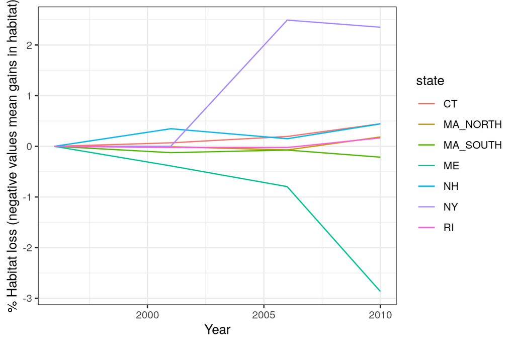

```r
state_cells <- map_df(states, get_cells_over_time) %>%
  bind_rows(s_mass_vals) %>%
  bind_rows(n_mass_vals)

#we want to compare each time period to the 1996 time period, not the previous one
perc_change_df <- state_cells %>%
  group_by(state) %>%
  mutate(first  = dplyr::first(num_wetland_cells),
         change = (1-(num_wetland_cells/first))*100) %>% #calculate % change from 1996
  ungroup() %>%
  mutate(state = toupper(state))

ggplot(perc_change_df, aes(x = as.numeric(year), y = change, color = state)) +
  geom_line() +
  theme_bw() +
  labs(x = "Year",
       y = "% Habitat loss (negative values mean gains in habitat)")
```

# Compare to historical loss

Maine is <1% according to Bromberg and Bertness (2005). They assign both 0% and <1% in the paper, but state that 569 ha have been lost. This is a non-zero amount of loss so without more information, we are setting Maine’s percent loss to 0.5%.

```r
hist_loss <- data.frame(state_name = c("Rhode Island", "Massachusetts", "New Hampshire", "Maine", "Connecticut", "New York"),
                        state = c("RI", "MA", "NH", "ME", "CT", "NY"),
                        hist_perc_loss = c(53, 41, 18, 0.5, 27, 48),
                        area_lost_ha = c(1831,13352,500, 569,2129,1032)) %>% #in hectares
                mutate(original_area = area_lost_ha/(0.01*hist_perc_loss),
                       prop_of_ne = original_area/sum(original_area)) #calculate the proportion of original salt marsh by state compared to the whole NE region

full_df <- perc_change_df %>%
  mutate(state2 = ifelse(str_detect(state, "MA"), "MA", state)) %>%
  left_join(hist_loss, by = c("state2" = "state")) %>%
  mutate(total_loss = change + hist_perc_loss,
         year = as.numeric(year),
         rgn_id = case_when(
           state == "CT" ~ 5,
           state == "ME" ~ 6,
           state == "MA_NORTH" ~ 7,
           state == "MA_SOUTH" ~ 8,
           state == "NH" ~ 9,
           state == "NY" ~ 10,
           state == "RI" ~ 11
         )) %>%
  left_join(rgn_data, by = "rgn_id") %>%
  select(rgn_id, rgn_name, year, total_loss, original_area)

ne_df <- full_df %>%
  mutate(area_lost = (total_loss/100) * original_area) %>%
  group_by(year) %>%
  summarize(original_area = sum(original_area),
            area_lost = sum(area_lost)) %>%
  ungroup() %>%
  mutate(total_loss = 100*(area_lost/original_area),
         rgn_id = 12,
         rgn_name = "Northeast") %>%
  select(-area_lost)

full_df <- bind_rows(full_df, ne_df)

#save for dashboard
write_csv(full_df, "data/salt_marsh_percent_change.csv")
```

# Save to toolbox

We need to save this data for the toolbox. We only have data points for a couple years in our time series. We will do a linear interpolation between points to gapfill `NA`. We also convert % loss to scores simply by inverting percent loss. So 75% loss gets a score of 25.

```r
toolbox_layer <- full_df %>%
  group_by(rgn_id, rgn_name) %>%
  complete(year = 1996:2010) %>% #only completing to 2010 for linear interpolation
  mutate(perc_loss = na.approx(total_loss)) %>%
  complete(year = 1996:2017) %>%
  mutate(perc_loss = na.locf(perc_loss)) %>% #now we carry forward the 2010 values for all years to 2017
  ungroup() %>%
  select(-total_loss)
```

# Results

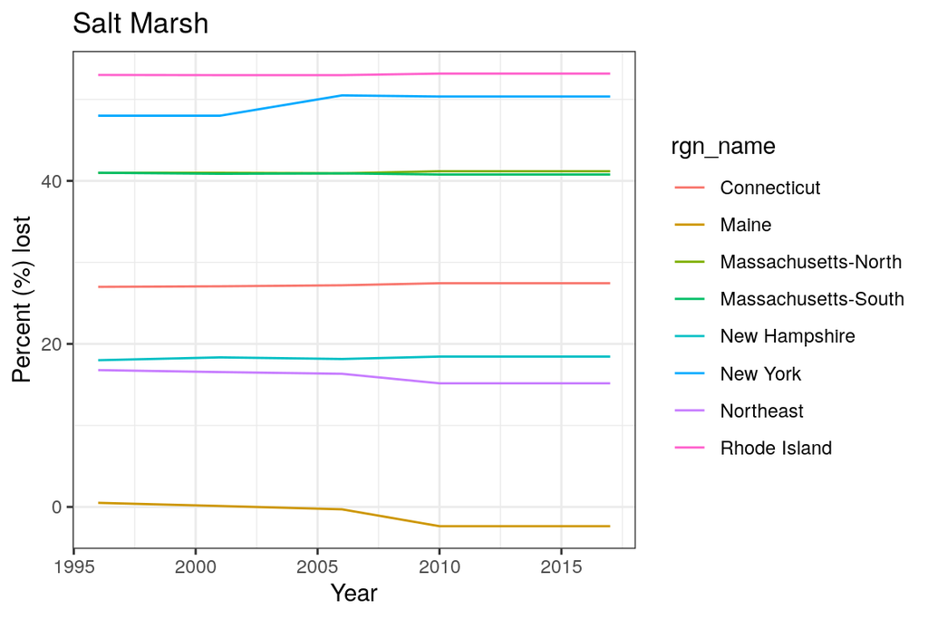

```r
ggplot(toolbox_layer, aes(x = year, y = perc_loss, color = rgn_name)) +
  geom_line() +
  theme_bw() +
  labs(x = "Year",
       y = "Percent (%) lost",
       title = "Salt Marsh")
```

Add in offshore regions with NA then save

```r
out <- toolbox_layer %>%
  complete(rgn_id = 1:12, year) %>%
  select(rgn_id, year, perc_loss) %>%
  mutate(habitat = "saltmarsh")
write_csv(out, file.path(dir_calc, "layers/hab_salt_marsh.csv"))
```